# Classical linear regression

Sebastian Sauer

2016-11-06 23:03:28

# 1 Setup

```r
library(knitr)
```

```r
opts_knit$set(root.dir=normalizePath('../'))


knitr::opts_chunk$set(echo = TRUE,
                      cache = TRUE,
                      warning = FALSE,
                      message = FALSE)
```

Load packages.

```r
source("analysis/functions/load_libs.R")
```

Define results variables.

```r
# results/ variables
mod_results_regression <- list()
regr_varimp <- list()  # var.imp only
```

Prepare overhead.

```r
registerDoMC(cores = 4)
```

Play or work (test it and recompute vs. rely on cached data)

```r
recompute <- TRUE
test_it <- TRUE

write_to_file <- FALSE
```

Define paths.

```r
source("analysis/functions/paths.R")
```

Load data and data-objects.

```r
data <- read_csv("raw_data/data_mod3.csv")

load(file = "data_objects/mod_results.Rda")
load("data_objects/important_predictors.Rda")
load("data_objects/important_predictors_overview.Rda")
```

Dimension of data:

Rows: 61. Cols: 46.

Check if *numeric* outcome variables is present in data frame. Check if *binary* outcome variable is present in data frame.

```r
str_detect(names(data), "CYBOCS") %>% any %>% expect_true

str_detect(names(data), "responder_3m") %>% any %>% expect_true
```

# 2 Simple non-sense regression models

If the number of predictors (p) equals the number of cases (n), then $R^2$ will approach 1. Hence, model fit *per se* is of limited or no value for deciding on the vlaue of a model.

## 2.1 Numeric outcome

Outcome: `CYBOCS_3m`.

```r
data %>%
 sample_n(45, replace = FALSE) %>%
  na.omit -> data2



if ("responder_3m_f" %in% names(data)) {
  dplyr::select(data2, -responder_3m_f) -> data2}


lm(CYBOCS_3m ~ ., data = data2) %>% summary %>% tidy %>% kable(digits = 3)
```

| term | estimate | std.error | statistic | p.value |
| --- | --- | --- | --- | --- |
| (Intercept) | -99.316 | 6.768 | -14.675 | 0.043 |
| CYBOCS_pre_OBS | -3.249 | 0.190 | -17.093 | 0.037 |
| CYBOCS_pre_COMP | 2.257 | 0.345 | 6.539 | 0.097 |
| CYBOCS_pre_insight | -3.875 | 0.541 | -7.161 | 0.088 |
| CYBOCS_pre_avoid | -1.748 | 0.436 | -4.010 | 0.156 |
| ChOCI_R_C_sumsym_PRE | -0.306 | 0.122 | -2.506 | 0.242 |
| ChOCI_R_C_sumimp_PRE | 0.721 | 0.074 | 9.727 | 0.065 |
| EWSASC_sum_PRE | 0.906 | 0.102 | 8.878 | 0.071 |
| SCAS_S_C_sum_PRE | -0.521 | 0.128 | -4.076 | 0.153 |
| CDI_S_sum_PRE | 0.485 | 0.243 | 1.991 | 0.296 |
| ChOCI_R_P_sumsym_PRE | -0.105 | 0.068 | -1.551 | 0.365 |
| ChOCI_R_P_sumimp_PRE | -0.307 | 0.063 | -4.894 | 0.128 |
| FAS_PR_sum_PRE | -0.502 | 0.087 | -5.773 | 0.109 |
| EWSASP_sum_PRE | 0.374 | 0.098 | 3.805 | 0.164 |
| SCAS_S_P_sum_PRE | 0.600 | 0.083 | 7.246 | 0.087 |
| Depression | -2.538 | 2.293 | -1.106 | 0.468 |
| PanicDisorder | -28.431 | 2.550 | -11.151 | 0.057 |
| SocialPhob | -18.232 | 2.104 | -8.666 | 0.073 |
| SpecificPhob | -15.443 | 2.125 | -7.268 | 0.087 |
| TourettesTics | 1.233 | 2.519 | 0.489 | 0.710 |
| ADHD | -1.225 | 1.250 | -0.980 | 0.506 |
| GAD | -13.830 | 2.425 | -5.703 | 0.110 |
| numberdiagnos | 5.314 | 1.764 | 3.012 | 0.204 |
| sexgirl | 5.445 | 0.822 | 6.622 | 0.095 |
| age | -6.318 | 1.817 | -3.477 | 0.178 |
| BirthcountrySweden | 16.287 | 1.542 | 10.559 | 0.060 |
| Education_parentHigh.school | -4.629 | 1.027 | -4.505 | 0.139 |
| Education_parentOther | 4.365 | 1.262 | 3.458 | 0.179 |
| Education_parentUniversity | 3.190 | 1.104 | 2.890 | 0.212 |
| OCDonset | 10.026 | 1.841 | 5.446 | 0.116 |
| yearswithOCD | 8.634 | 1.892 | 4.562 | 0.137 |
| contactSelf.referral | 14.520 | 1.685 | 8.617 | 0.074 |
| distance | 0.001 | 0.007 | 0.143 | 0.909 |
| medicationnone | 3.639 | 2.733 | 1.331 | 0.410 |
| medicationSSRI | 19.966 | 3.074 | 6.495 | 0.097 |
| treatm_expCAMHS.councelling | -3.536 | 2.625 | -1.347 | 0.406 |
| treatm_expnone | -2.131 | 2.490 | -0.856 | 0.549 |
| OCD_treatm_expnone | 34.727 | 3.099 | 11.206 | 0.057 |
| CGI_S_pre | -2.374 | 1.083 | -2.193 | 0.272 |
| checking | 1.108 | 1.133 | 0.978 | 0.507 |
| obsessions | 3.021 | 0.613 | 4.927 | 0.127 |
| contamination | 4.720 | 1.512 | 3.121 | 0.197 |
| symmetry | 2.600 | 1.258 | 2.067 | 0.287 |
| CBT_OCD | 43.880 | 2.909 | 15.082 | 0.042 |

$R^2$ of this model is: 0.9996208.

## 2.2 Binary regression models

Outcome: `responder_3m_f`.

```r
data %>%
 dplyr::sample_n(45, replace = FALSE) %>%
  na.omit -> data2


if ("CYBOCS_3m" %in% names(data)) {
  dplyr::select(data2, -CYBOCS_3m) -> data2}


glm(responder_3m_f ~ ., data = data2, family = "binomial") %>% summary
```

```
##
## Call:
## glm(formula = responder_3m_f ~ ., family = "binomial", data = data2)
##
## Deviance Residuals:
##          1           2           3           4           5           6
## -3.380e-06   2.879e-06   2.110e-08   2.571e-06   2.694e-06  -2.812e-06
##          7           8           9          10          11          12
##  2.976e-06  -2.492e-06   2.091e-06   2.451e-06  -3.458e-06  -2.997e-06
##         13          14          15          16          17          18
## -2.480e-06  -3.149e-06   3.413e-06   2.785e-06   2.305e-06  -1.396e-06
##         19          20          21          22          23          24
## -1.396e-06   2.400e-06   2.864e-06   2.768e-06  -1.586e-06  -1.048e-06
##         25          26          27          28          29          30
##  1.621e-06   2.491e-06   2.768e-06   1.458e-06   2.409e-06   1.895e-06
##         31          32          33          34          35          36
##  2.049e-06   2.693e-06   1.896e-06   2.409e-06   2.492e-06  -2.017e-06
##         37          38          39          40          41          42
## -2.336e-06  -2.130e-06   2.564e-06   2.070e-06  -1.901e-06   2.814e-06
##         43          44          45
##  2.039e-06   2.509e-06  -2.955e-06
##
## Coefficients: (1 not defined because of singularities)
##                               Estimate Std. Error z value Pr(>|z|)
## (Intercept)                 -4.970e+01  1.145e+07       0        1
## CYBOCS_pre_OBS              -2.503e+00  3.843e+05       0        1
## CYBOCS_pre_COMP             -8.062e+00  3.132e+05       0        1
## CYBOCS_pre_insight           2.000e+00  2.844e+05       0        1
## CYBOCS_pre_avoid             3.042e+00  1.958e+05       0        1
## ChOCI_R_C_sumsym_PRE        -6.845e-01  1.931e+05       0        1
## ChOCI_R_C_sumimp_PRE         3.314e+00  1.690e+05       0        1
## EWSASC_sum_PRE              -3.207e+00  1.060e+05       0        1
## SCAS_S_C_sum_PRE             2.774e+00  1.857e+05       0        1
## CDI_S_sum_PRE               -3.408e+00  3.464e+05       0        1
## ChOCI_R_P_sumsym_PRE         1.312e+00  9.054e+04       0        1
## ChOCI_R_P_sumimp_PRE         1.841e+00  7.316e+04       0        1
## FAS_PR_sum_PRE               2.557e-01  1.063e+05       0        1
## EWSASP_sum_PRE              -7.079e-01  6.024e+04       0        1
## SCAS_S_P_sum_PRE            -9.193e-01  2.421e+05       0        1
## Depression                   8.131e+01  4.890e+06       0        1
```

[output cut: 22 more lines]

```
## OCD_treatm_expnone           4.207e+01  2.058e+06       0        1
## CGI_S_pre                    3.331e+01  1.082e+06       0        1
## checking                    -6.619e+00  6.196e+05       0        1
## obsessions                   2.135e+01  5.386e+05       0        1
## contamination                1.991e+01  1.384e+06       0        1
## symmetry                     8.327e+00  1.644e+06       0        1
## CBT_OCD                      6.526e+01  2.973e+06       0        1
##
## (Dispersion parameter for binomial family taken to be 1)
##
##     Null deviance: 5.8574e+01  on 44  degrees of freedom
## Residual deviance: 2.6850e-10  on  1  degrees of freedom
## AIC: 88
##
## Number of Fisher Scoring iterations: 25
```

$R^2$ of this model is:

```r
glm(data2$responder_3m_f ~ .,
               data = data2,
               family = "binomial",
               control = list(maxit = 50)) %>%
  pR2(.) %>%
  print
```

```
##           llh       llhNull            G2      McFadden          r2ML
## -1.342428e-10 -2.928681e+01  5.857363e+01  1.000000e+00  7.279137e-01
##          r2CU
##  1.000000e+00
```

# 3 Bivariate variable selection models (regression/ numeric outcome)

Now, let’s take the *full* sample, and check whether/how strong each predictor is correlated with the (metric) outcome. Predictors which are correlated (p<.05) with the outcome will be used for the predicting the outcome in the next step.

As the sample size is low, it can be argued that it is better not to split up the sample, but to use some overfitting-aware measure on the performance of the whole sample. Adjusted $R^2$ would be some sensible measure.

## 3.1 Predictor selection

We compute a regression with *one* predictor, and repeat that for each predictor. The p-value is taken as criterion of “relevant” predictor. This choise is debatable, but let’s leave that for now.

```r
data %>%
  dplyr::select(-c(responder_3m_f, CYBOCS_3m)) %>%
  map(~lm(data$CYBOCS_3m ~ .x, data = data)) %>%
  map(tidy, conf.int = TRUE) %>%
  # map(summary) %>%
  # map("coefficients") %>%
  do.call(rbind.data.frame, .) %>%
  rownames_to_column %>%
  as_tibble %>%
  dplyr::rename(predictor = rowname, p = p.value, b = estimate, SE = std.error, t = statistic) %>%
  # setNames(c("predictor", "b", "SE", "t", "p", "conf.low", "conf.hi")) %>%
  dplyr::arrange(p) %>%
  filter(!str_detect(term, "(Intercept)")) %>%
  dplyr::select(-term) %>%
  mutate(predictor = str_sub(predictor, start = 1, end = str_length(predictor)-2))  -> mod_results$classical_01$univariate_lm_selection



mod_results$classical_01$univariate_lm_selection %>%
  mutate_at(vars(b, SE, t, conf.low, conf.high), funs(round(., 2))) %>%
  mutate(p = round(p, 3)) %>%
  mutate(p = ifelse(p == 0, 0.001, p)) %>%
  kable
```

| predictor | b | SE | t | p | conf.low | conf.high |
| --- | --- | --- | --- | --- | --- | --- |
| yearswithOCD | 1.06 | 0.27 | 3.86 | 0.001 | 0.51 | 1.61 |
| OCD_treatm_expnone | -6.30 | 1.73 | -3.64 | 0.001 | -9.77 | -2.84 |
| CGI_S_pre | 3.57 | 1.02 | 3.51 | 0.001 | 1.53 | 5.60 |
| CBT_OCD | 5.88 | 1.81 | 3.26 | 0.002 | 2.27 | 9.50 |
| ChOCI_R_P_sumimp_PRE | 0.30 | 0.10 | 3.00 | 0.004 | 0.10 | 0.50 |
| EWSASP_sum_PRE | 0.26 | 0.09 | 2.98 | 0.004 | 0.08 | 0.43 |
| OCDonset | -0.87 | 0.30 | -2.92 | 0.005 | -1.47 | -0.27 |
| SCAS_S_P_sum_PRE | 0.37 | 0.13 | 2.85 | 0.006 | 0.11 | 0.64 |
| ADHD | 6.08 | 2.65 | 2.29 | 0.025 | 0.77 | 11.40 |
| ChOCI_R_C_sumimp_PRE | 0.25 | 0.11 | 2.23 | 0.029 | 0.03 | 0.48 |
| FAS_PR_sum_PRE | 0.15 | 0.07 | 2.20 | 0.032 | 0.01 | 0.30 |
| CDI_S_sum_PRE | 0.52 | 0.24 | 2.19 | 0.032 | 0.05 | 1.00 |
| EWSASC_sum_PRE | 0.18 | 0.09 | 2.10 | 0.040 | 0.01 | 0.35 |
| medication_yesno | 3.65 | 1.86 | 1.97 | 0.054 | -0.06 | 7.36 |
| medicationnone | -3.65 | 1.86 | -1.97 | 0.054 | -7.36 | 0.06 |
| CYBOCS_pre_COMP | 0.71 | 0.36 | 1.94 | 0.057 | -0.02 | 1.43 |
| ChOCI_R_P_sumsym_PRE | 0.26 | 0.15 | 1.71 | 0.092 | -0.04 | 0.56 |
| CYBOCS_pre_avoid | 1.38 | 0.85 | 1.62 | 0.111 | -0.33 | 3.08 |
| sexgirl | 2.50 | 1.64 | 1.53 | 0.132 | -0.77 | 5.77 |
| age | 0.65 | 0.49 | 1.33 | 0.187 | -0.33 | 1.63 |
| Education_parentHigh.school | -2.37 | 1.94 | -1.22 | 0.227 | -6.24 | 1.51 |
| checking | 1.98 | 1.72 | 1.15 | 0.254 | -1.46 | 5.41 |
| Education_parentUniversity | 1.86 | 1.63 | 1.14 | 0.258 | -1.40 | 5.13 |
| symmetry | -1.59 | 1.74 | -0.91 | 0.365 | -5.08 | 1.90 |
| SocialPhob | 2.64 | 2.99 | 0.88 | 0.381 | -3.34 | 8.61 |
| obsessions | 1.43 | 1.64 | 0.87 | 0.387 | -1.85 | 4.72 |
| Depression | 2.42 | 2.99 | 0.81 | 0.422 | -3.57 | 8.40 |
| GAD | -1.93 | 2.43 | -0.80 | 0.429 | -6.80 | 2.93 |
| CYBOCS_pre_OBS | 0.27 | 0.34 | 0.79 | 0.431 | -0.42 | 0.96 |
| BirthcountrySweden | -2.20 | 2.99 | -0.73 | 0.465 | -8.19 | 3.79 |
| ChOCI_R_C_sumsym_PRE | 0.09 | 0.12 | 0.71 | 0.480 | -0.16 | 0.33 |
| SCAS_S_C_sum_PRE | 0.08 | 0.13 | 0.61 | 0.543 | -0.18 | 0.35 |
| medicationSSRI | 1.22 | 2.14 | 0.57 | 0.570 | -3.06 | 5.50 |
| numberdiagnos | 0.50 | 0.88 | 0.57 | 0.572 | -1.26 | 2.25 |
| CYBOCS_pre_insight | 0.55 | 1.03 | 0.53 | 0.597 | -1.52 | 2.62 |
| treatm_expnone | -0.77 | 1.65 | -0.47 | 0.641 | -4.07 | 2.53 |
| contamination | 0.78 | 1.71 | 0.45 | 0.651 | -2.65 | 4.21 |
| SpecificPhob | 0.76 | 2.59 | 0.30 | 0.769 | -4.41 | 5.94 |
| treatm_expCAMHS.councelling | -0.43 | 1.69 | -0.26 | 0.798 | -3.81 | 2.94 |
| TourettesTics | -0.73 | 3.33 | -0.22 | 0.828 | -7.39 | 5.94 |
| Education_parentOther | -0.47 | 2.33 | -0.20 | 0.840 | -5.12 | 4.18 |
| contactSelf.referral | -0.46 | 3.01 | -0.15 | 0.880 | -6.47 | 5.56 |
| distance | 0.00 | 0.01 | 0.15 | 0.884 | -0.01 | 0.02 |
| PanicDisorder | 0.24 | 3.01 | 0.08 | 0.937 | -5.78 | 6.26 |

According to this reasoning, we should retain the following variables (p < .05):

```r
mod_results$classical_01$univariate_lm_selection %>%
  filter(p < .05) %>%
  filter(!str_detect(predictor, "(Intercept)")) -> mod_results$classical_01$univariate_lm_selection_signif

mod_results$classical_01$univariate_lm_selection_signif %>%
  mutate_at(vars(b, SE, t), funs(round(., 2))) %>%
  mutate(p = ifelse(p < 0.01, 0.001, round(p, 3))) %>%
  kable
```

| predictor | b | SE | t | p | conf.low | conf.high |
| --- | --- | --- | --- | --- | --- | --- |
| yearswithOCD | 1.06 | 0.27 | 3.86 | 0.001 | 0.5109581 | 1.6091790 |
| OCD_treatm_expnone | -6.30 | 1.73 | -3.64 | 0.001 | -9.7665767 | -2.8392204 |
| CGI_S_pre | 3.57 | 1.02 | 3.51 | 0.001 | 1.5334377 | 5.6006845 |
| CBT_OCD | 5.88 | 1.81 | 3.26 | 0.001 | 2.2709579 | 9.4980391 |
| ChOCI_R_P_sumimp_PRE | 0.30 | 0.10 | 3.00 | 0.001 | 0.0993053 | 0.4966646 |
| EWSASP_sum_PRE | 0.26 | 0.09 | 2.98 | 0.001 | 0.0849744 | 0.4307431 |
| OCDonset | -0.87 | 0.30 | -2.92 | 0.001 | -1.4691997 | -0.2748815 |
| SCAS_S_P_sum_PRE | 0.37 | 0.13 | 2.85 | 0.001 | 0.1120142 | 0.6378694 |
| ADHD | 6.08 | 2.65 | 2.29 | 0.025 | 0.7736168 | 11.3960802 |
| ChOCI_R_C_sumimp_PRE | 0.25 | 0.11 | 2.23 | 0.029 | 0.0263449 | 0.4835664 |
| FAS_PR_sum_PRE | 0.15 | 0.07 | 2.20 | 0.032 | 0.0141706 | 0.2951397 |
| CDI_S_sum_PRE | 0.52 | 0.24 | 2.19 | 0.032 | 0.0458155 | 0.9995486 |
| EWSASC_sum_PRE | 0.18 | 0.09 | 2.10 | 0.040 | 0.0083714 | 0.3493243 |

In sum, 13 variables were chosen.

Let’s also have a look at the (adj.) R squared of each model

```r
data %>%
  dplyr::select(-c(responder_3m_f, CYBOCS_3m)) %>%
  map(~lm(data$CYBOCS_3m ~ .x, data = data)) %>%
  map(glance) %>%
  do.call(rbind.data.frame, .) %>%
  rownames_to_column %>%
  as_tibble %>%
  arrange(-r.squared) %>%
  kable(digits = 3)
```

| rowname | r.squared | adj.r.squared | sigma | statistic | p.value | df | logLik | AIC | BIC | deviance | df.residual |
| --- | --- | --- | --- | --- | --- | --- | --- | --- | --- | --- | --- |
| yearswithOCD | 0.202 | 0.188 | 5.756 | 14.922 | 0.000 | 2 | -192.301 | 390.603 | 396.936 | 1954.642 | 59 |
| OCD_treatm_expnone | 0.183 | 0.170 | 5.822 | 13.259 | 0.001 | 2 | -192.996 | 391.992 | 398.324 | 1999.651 | 59 |
| CGI_S_pre | 0.173 | 0.159 | 5.860 | 12.319 | 0.001 | 2 | -193.395 | 392.790 | 399.123 | 2025.998 | 59 |
| CBT_OCD | 0.153 | 0.138 | 5.931 | 10.618 | 0.002 | 2 | -194.131 | 394.262 | 400.595 | 2075.495 | 59 |
| ChOCI_R_P_sumimp_PRE | 0.132 | 0.118 | 6.001 | 9.007 | 0.004 | 2 | -194.845 | 395.691 | 402.023 | 2124.667 | 59 |
| EWSASP_sum_PRE | 0.131 | 0.116 | 6.005 | 8.907 | 0.004 | 2 | -194.890 | 395.780 | 402.113 | 2127.784 | 59 |
| OCDonset | 0.126 | 0.112 | 6.022 | 8.539 | 0.005 | 2 | -195.056 | 396.112 | 402.445 | 2139.399 | 59 |
| SCAS_S_P_sum_PRE | 0.121 | 0.106 | 6.039 | 8.142 | 0.006 | 2 | -195.236 | 396.471 | 402.804 | 2152.026 | 59 |
| ADHD | 0.082 | 0.066 | 6.174 | 5.255 | 0.025 | 2 | -196.576 | 399.152 | 405.485 | 2248.715 | 59 |
| ChOCI_R_C_sumimp_PRE | 0.078 | 0.062 | 6.187 | 4.980 | 0.029 | 2 | -196.707 | 399.414 | 405.747 | 2258.393 | 59 |
| FAS_PR_sum_PRE | 0.076 | 0.060 | 6.193 | 4.852 | 0.032 | 2 | -196.768 | 399.536 | 405.868 | 2262.903 | 59 |
| CDI_S_sum_PRE | 0.075 | 0.060 | 6.195 | 4.810 | 0.032 | 2 | -196.788 | 399.576 | 405.909 | 2264.398 | 59 |
| EWSASC_sum_PRE | 0.070 | 0.054 | 6.215 | 4.407 | 0.040 | 2 | -196.982 | 399.963 | 406.296 | 2278.806 | 59 |
| medicationnone | 0.062 | 0.046 | 6.241 | 3.870 | 0.054 | 2 | -197.241 | 400.482 | 406.814 | 2298.259 | 59 |
| medication_yesno | 0.062 | 0.046 | 6.241 | 3.870 | 0.054 | 2 | -197.241 | 400.482 | 406.814 | 2298.259 | 59 |
| CYBOCS_pre_COMP | 0.060 | 0.044 | 6.246 | 3.781 | 0.057 | 2 | -197.284 | 400.568 | 406.901 | 2301.524 | 59 |
| ChOCI_R_P_sumsym_PRE | 0.047 | 0.031 | 6.288 | 2.938 | 0.092 | 2 | -197.697 | 401.393 | 407.726 | 2332.860 | 59 |
| CYBOCS_pre_avoid | 0.043 | 0.026 | 6.304 | 2.620 | 0.111 | 2 | -197.853 | 401.707 | 408.039 | 2344.887 | 59 |
| sexgirl | 0.038 | 0.022 | 6.319 | 2.337 | 0.132 | 2 | -197.994 | 401.987 | 408.320 | 2355.697 | 59 |
| age | 0.029 | 0.013 | 6.348 | 1.781 | 0.187 | 2 | -198.272 | 402.543 | 408.876 | 2377.269 | 59 |
| Education_parentHigh.school | 0.025 | 0.008 | 6.363 | 1.492 | 0.227 | 2 | -198.417 | 402.834 | 409.167 | 2388.619 | 59 |
| checking | 0.022 | 0.005 | 6.372 | 1.325 | 0.254 | 2 | -198.501 | 403.003 | 409.335 | 2395.238 | 59 |
| Education_parentUniversity | 0.022 | 0.005 | 6.373 | 1.304 | 0.258 | 2 | -198.512 | 403.024 | 409.357 | 2396.076 | 59 |
| symmetry | 0.014 | -0.003 | 6.398 | 0.832 | 0.365 | 2 | -198.752 | 403.503 | 409.836 | 2414.970 | 59 |
| SocialPhob | 0.013 | -0.004 | 6.401 | 0.778 | 0.381 | 2 | -198.779 | 403.558 | 409.890 | 2417.129 | 59 |
| obsessions | 0.013 | -0.004 | 6.402 | 0.760 | 0.387 | 2 | -198.788 | 403.576 | 409.909 | 2417.862 | 59 |
| Depression | 0.011 | -0.006 | 6.407 | 0.654 | 0.422 | 2 | -198.843 | 403.685 | 410.018 | 2422.182 | 59 |
| GAD | 0.011 | -0.006 | 6.408 | 0.633 | 0.429 | 2 | -198.853 | 403.706 | 410.039 | 2423.019 | 59 |
| CYBOCS_pre_OBS | 0.011 | -0.006 | 6.409 | 0.627 | 0.431 | 2 | -198.856 | 403.712 | 410.045 | 2423.248 | 59 |
| BirthcountrySweden | 0.009 | -0.008 | 6.413 | 0.540 | 0.465 | 2 | -198.901 | 403.801 | 410.134 | 2426.800 | 59 |
| ChOCI_R_C_sumsym_PRE | 0.008 | -0.008 | 6.415 | 0.506 | 0.480 | 2 | -198.918 | 403.837 | 410.169 | 2428.211 | 59 |
| SCAS_S_C_sum_PRE | 0.006 | -0.011 | 6.422 | 0.375 | 0.543 | 2 | -198.985 | 403.971 | 410.304 | 2433.562 | 59 |
| medicationSSRI | 0.005 | -0.011 | 6.425 | 0.326 | 0.570 | 2 | -199.010 | 404.021 | 410.354 | 2435.556 | 59 |
| numberdiagnos | 0.005 | -0.011 | 6.425 | 0.323 | 0.572 | 2 | -199.012 | 404.024 | 410.356 | 2435.672 | 59 |
| CYBOCS_pre_insight | 0.005 | -0.012 | 6.427 | 0.282 | 0.597 | 2 | -199.033 | 404.066 | 410.398 | 2437.349 | 59 |
| treatm_expnone | 0.004 | -0.013 | 6.431 | 0.220 | 0.641 | 2 | -199.065 | 404.130 | 410.463 | 2439.909 | 59 |
| contamination | 0.003 | -0.013 | 6.431 | 0.207 | 0.651 | 2 | -199.072 | 404.144 | 410.476 | 2440.465 | 59 |
| SpecificPhob | 0.001 | -0.015 | 6.438 | 0.087 | 0.769 | 2 | -199.133 | 404.267 | 410.599 | 2445.394 | 59 |
| treatm_expCAMHS.councelling | 0.001 | -0.016 | 6.439 | 0.066 | 0.798 | 2 | -199.144 | 404.289 | 410.621 | 2446.266 | 59 |
| TourettesTics | 0.001 | -0.016 | 6.440 | 0.048 | 0.828 | 2 | -199.154 | 404.308 | 410.640 | 2447.035 | 59 |
| Education_parentOther | 0.001 | -0.016 | 6.440 | 0.041 | 0.840 | 2 | -199.157 | 404.315 | 410.647 | 2447.306 | 59 |
| contactSelf.referral | 0.000 | -0.017 | 6.441 | 0.023 | 0.880 | 2 | -199.167 | 404.333 | 410.666 | 2448.057 | 59 |
| distance | 0.000 | -0.017 | 6.442 | 0.022 | 0.884 | 2 | -199.167 | 404.335 | 410.668 | 2448.124 | 59 |
| PanicDisorder | 0.000 | -0.017 | 6.442 | 0.006 | 0.937 | 2 | -199.175 | 404.351 | 410.683 | 2448.754 | 59 |

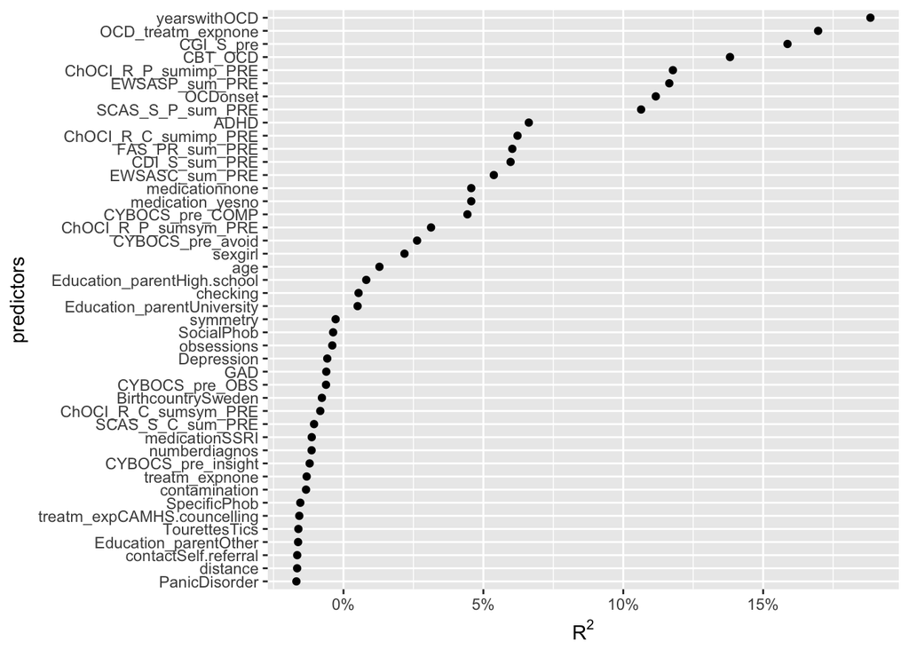

```r
data %>%
  dplyr::select(-c(responder_3m_f, CYBOCS_3m)) %>%
  map(~lm(data$CYBOCS_3m ~ .x, data = data)) %>%
  map(glance) %>%
  do.call(rbind.data.frame, .) %>%
  rownames_to_column %>%
  as_tibble %>%
  ggplot(aes(x = reorder(rowname, adj.r.squared), y = adj.r.squared)) +
  geom_point() +
  coord_flip() +
  scale_y_continuous(labels = scales::percent) +
  xlab("predictors") +
  ylab(expression(R^{2}))
```

And now the $R^2$ for the significant predictors only:

```r
data %>%
  dplyr::select(one_of(mod_results$classical_01$univariate_lm_selection_signif$predictor)) -> mod_results$classical_01$univariate_signif_preds_df

mod_results$classical_01$univariate_signif_preds_df %>%
  map(~lm(data$CYBOCS_3m ~ .x, data = mod_results$classical_01$univariate_signif_preds_df)) %>%   map(glance) %>%
  do.call(rbind.data.frame, .) %>%
  rownames_to_column %>%
  as_tibble %>%
  arrange(-r.squared) %>%
  kable(digits = 3)
```

| rowname | r.squared | adj.r.squared | sigma | statistic | p.value | df | logLik | AIC | BIC | deviance | df.residual |
| --- | --- | --- | --- | --- | --- | --- | --- | --- | --- | --- | --- |
| yearswithOCD | 0.202 | 0.188 | 5.756 | 14.922 | 0.000 | 2 | -192.301 | 390.603 | 396.936 | 1954.642 | 59 |
| OCD_treatm_expnone | 0.183 | 0.170 | 5.822 | 13.259 | 0.001 | 2 | -192.996 | 391.992 | 398.324 | 1999.651 | 59 |
| CGI_S_pre | 0.173 | 0.159 | 5.860 | 12.319 | 0.001 | 2 | -193.395 | 392.790 | 399.123 | 2025.998 | 59 |
| CBT_OCD | 0.153 | 0.138 | 5.931 | 10.618 | 0.002 | 2 | -194.131 | 394.262 | 400.595 | 2075.495 | 59 |
| ChOCI_R_P_sumimp_PRE | 0.132 | 0.118 | 6.001 | 9.007 | 0.004 | 2 | -194.845 | 395.691 | 402.023 | 2124.667 | 59 |
| EWSASP_sum_PRE | 0.131 | 0.116 | 6.005 | 8.907 | 0.004 | 2 | -194.890 | 395.780 | 402.113 | 2127.784 | 59 |
| OCDonset | 0.126 | 0.112 | 6.022 | 8.539 | 0.005 | 2 | -195.056 | 396.112 | 402.445 | 2139.399 | 59 |
| SCAS_S_P_sum_PRE | 0.121 | 0.106 | 6.039 | 8.142 | 0.006 | 2 | -195.236 | 396.471 | 402.804 | 2152.026 | 59 |
| ADHD | 0.082 | 0.066 | 6.174 | 5.255 | 0.025 | 2 | -196.576 | 399.152 | 405.485 | 2248.715 | 59 |
| ChOCI_R_C_sumimp_PRE | 0.078 | 0.062 | 6.187 | 4.980 | 0.029 | 2 | -196.707 | 399.414 | 405.747 | 2258.393 | 59 |
| FAS_PR_sum_PRE | 0.076 | 0.060 | 6.193 | 4.852 | 0.032 | 2 | -196.768 | 399.536 | 405.868 | 2262.903 | 59 |
| CDI_S_sum_PRE | 0.075 | 0.060 | 6.195 | 4.810 | 0.032 | 2 | -196.788 | 399.576 | 405.909 | 2264.398 | 59 |
| EWSASC_sum_PRE | 0.070 | 0.054 | 6.215 | 4.407 | 0.040 | 2 | -196.982 | 399.963 | 406.296 | 2278.806 | 59 |

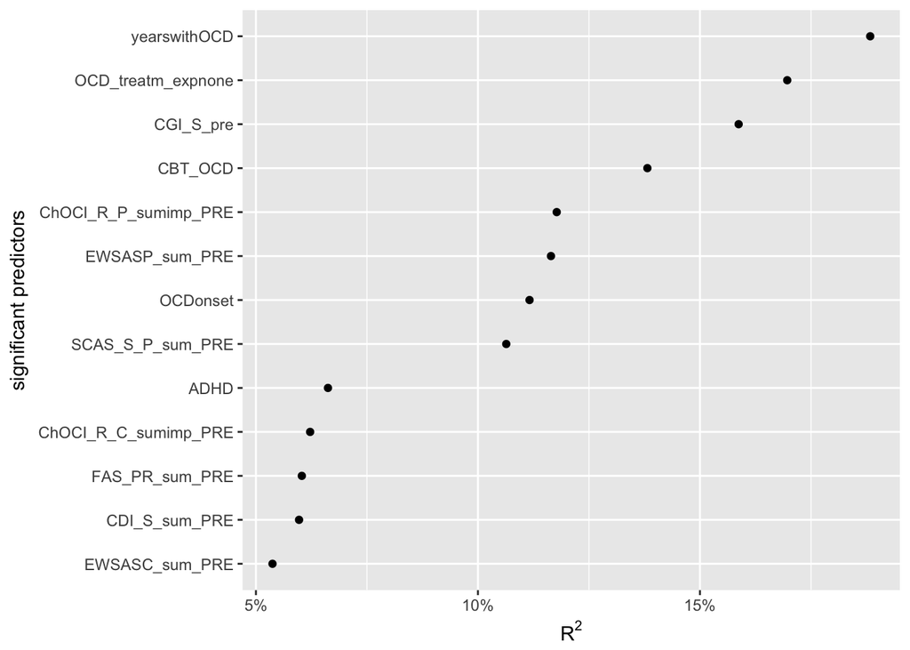

```r
mod_results$classical_01$univariate_signif_preds_df %>%
  map(~lm(data$CYBOCS_3m ~ .x, data = mod_results$classical_01$univariate_signif_preds_df)) %>%   map(glance) %>%
  do.call(rbind.data.frame, .) %>%
  rownames_to_column %>%
  as_tibble %>%
  arrange(-r.squared) %>%
  ggplot(aes(x = reorder(rowname, adj.r.squared), y = adj.r.squared)) +
  geom_point() +
  coord_flip() +
  scale_y_continuous(labels = scales::percent) +
  xlab("significant predictors") +
  ylab(expression(R^{2}))
```

## 3.2 Regression with univariate predictor selection (numeric outcome)

We take these predictors (which showed a statistical significant assocation with the outcome in bivariate regressions), and submit them to a multivariate regression.

```r
data %>%
  dplyr::select(one_of(mod_results$classical_01$univariate_lm_selection_signif$predictor))  -> data_regr_univar_signif

lm(data$CYBOCS_3m ~ . , data = data_regr_univar_signif) %>%
  tidy(conf.int = TRUE) %>%
  arrange(p.value) ->  mod_results$classical_01$lm1_tidy



mod_results$classical_01$lm1_tidy %>%
  kable(digits = 3)
```

| term | estimate | std.error | statistic | p.value | conf.low | conf.high |
| --- | --- | --- | --- | --- | --- | --- |
| ADHD | 4.260 | 2.684 | 1.587 | 0.119 | -1.139 | 9.659 |
| yearswithOCD | 0.714 | 0.515 | 1.386 | 0.172 | -0.322 | 1.751 |
| SCAS_S_P_sum_PRE | 0.147 | 0.155 | 0.947 | 0.348 | -0.165 | 0.458 |
| ChOCI_R_P_sumimp_PRE | 0.129 | 0.143 | 0.905 | 0.370 | -0.158 | 0.416 |
| EWSASP_sum_PRE | -0.095 | 0.143 | -0.664 | 0.510 | -0.382 | 0.193 |
| CBT_OCD | 4.061 | 6.483 | 0.626 | 0.534 | -8.980 | 17.103 |
| CDI_S_sum_PRE | 0.147 | 0.291 | 0.507 | 0.614 | -0.437 | 0.732 |
| EWSASC_sum_PRE | 0.062 | 0.124 | 0.497 | 0.621 | -0.188 | 0.311 |
| CGI_S_pre | 0.590 | 1.399 | 0.422 | 0.675 | -2.225 | 3.405 |
| OCDonset | 0.123 | 0.486 | 0.254 | 0.801 | -0.854 | 1.101 |
| FAS_PR_sum_PRE | 0.018 | 0.087 | 0.211 | 0.834 | -0.157 | 0.193 |
| ChOCI_R_C_sumimp_PRE | 0.015 | 0.172 | 0.085 | 0.933 | -0.332 | 0.361 |
| OCD_treatm_expnone | -0.510 | 6.510 | -0.078 | 0.938 | -13.607 | 12.588 |
| (Intercept) | 0.405 | 10.086 | 0.040 | 0.968 | -19.885 | 20.694 |

## 3.3 Number of significant predictors

How many predictors reach statistical significance?

```r
mod_results$classical_01$lm1_tidy %>%
  filter(p.value < .05) %>%
  nrow
```

```
## [1] 0
```

```r
stargazer(mod_results$classical_01$lm1_tidy, type = "html")
```

| Statistic | N | Mean | St. Dev. | Min | Max |
| --- | --- | --- | --- | --- | --- |
| estimate | 14 | 0.719 | 1.488 | -0.510 | 4.260 |
| std.error | 14 | 2.091 | 3.220 | 0.087 | 10.086 |
| statistic | 14 | 0.480 | 0.593 | -0.664 | 1.587 |
| p.value | 14 | 0.603 | 0.278 | 0.119 | 0.968 |
| conf.low | 14 | -3.488 | 6.193 | -19.885 | -0.157 |
| conf.high | 14 | 4.926 | 7.070 | 0.193 | 20.694 |

Let’s have a look at the predictors which reached statistical significance:

```r
mod_results$classical_01$lm1_tidy %>%
  filter(p.value < .05) %>%
  mutate_if(is.numeric, round, digits = 2) -> mod_results$classical_01$signif_preds

mod_results$classical_01$signif_preds %>%
  kable(digits = 3)
```

## 3.4 Adj. R squared

*Adjusted* $R^2$ of the *whole* dataset is:

```r
lm(data$CYBOCS_3m ~ . , data = data_regr_univar_signif) %>%
  glance %>%
  arrange(-r.squared) %>%
  kable
```

| r.squared | adj.r.squared | sigma | statistic | p.value | df | logLik | AIC | BIC | deviance | df.residual |
| --- | --- | --- | --- | --- | --- | --- | --- | --- | --- | --- |
| 0.4393043 | 0.2842183 | 5.405184 | 2.832649 | 0.0044861 | 14 | -181.532 | 393.0639 | 424.7271 | 1373.153 | 47 |

## 3.5 Regression diagnistics

```r
lm(data$CYBOCS_3m ~ . , data = data_regr_univar_signif) %>%
  augment %>%
  kable(digits = 3)
```

| data.CYBOCS_3m | yearswithOCD | OCD_treatm_expnone | CGI_S_pre | CBT_OCD | ChOCI_R_P_sumimp_PRE | EWSASP_sum_PRE | OCDonset | SCAS_S_P_sum_PRE | ADHD | ChOCI_R_C_sumimp_PRE | FAS_PR_sum_PRE | CDI_S_sum_PRE | EWSASC_sum_PRE | .fitted | .se.fit | .resid | .hat | .sigma | .cooksd | .std.resid |
| --- | --- | --- | --- | --- | --- | --- | --- | --- | --- | --- | --- | --- | --- | --- | --- | --- | --- | --- | --- | --- |
| 12 | 1 | 1 | 3 | 0 | 14 | 10 | 11 | 5 | 0 | 14 | 8 | 2 | 10 | 6.592 | 1.917 | 5.408 | 0.126 | 5.397 | 0.012 | 1.070 |
| 11 | 1 | 1 | 3 | 0 | 35 | 20 | 13 | 17 | 0 | 20 | 13 | 5 | 6 | 10.736 | 2.173 | 0.264 | 0.162 | 5.463 | 0.000 | 0.053 |
| 7 | 3 | 0 | 3 | 1 | 29 | 9 | 10 | 1 | 0 | 9 | 4 | 1 | 4 | 13.250 | 3.129 | -6.250 | 0.335 | 5.345 | 0.072 | -1.418 |
| 9 | 0 | 1 | 3 | 0 | 29 | 14 | 13 | 11 | 0 | 30 | 9 | 6 | 17 | 9.835 | 2.055 | -0.835 | 0.145 | 5.462 | 0.000 | -0.167 |
| 4 | 2 | 1 | 3 | 0 | 33 | 27 | 12 | 6 | 0 | 31 | 4 | 0 | 12 | 8.421 | 3.333 | -4.421 | 0.380 | 5.401 | 0.047 | -1.039 |
| 9 | 2 | 1 | 3 | 0 | 21 | 6 | 11 | 7 | 0 | 20 | 2 | 2 | 9 | 8.799 | 1.491 | 0.201 | 0.076 | 5.464 | 0.000 | 0.039 |
| 21 | 5 | 0 | 3 | 1 | 32 | 19 | 9 | 9 | 0 | 16 | 29 | 1 | 4 | 15.727 | 2.105 | 5.273 | 0.152 | 5.398 | 0.014 | 1.059 |
| 22 | 5 | 0 | 3 | 1 | 27 | 26 | 7 | 14 | 0 | 16 | 30 | 2 | 18 | 15.932 | 2.552 | 6.068 | 0.223 | 5.369 | 0.033 | 1.273 |
| 0 | 1 | 1 | 2 | 0 | 4 | 0 | 14 | 1 | 0 | 12 | 4 | 3 | 9 | 5.427 | 2.641 | -5.427 | 0.239 | 5.386 | 0.030 | -1.151 |
| 20 | 5 | 0 | 5 | 1 | 33 | 30 | 8 | 12 | 1 | 22 | 37 | 2 | 10 | 21.321 | 3.071 | -1.321 | 0.323 | 5.458 | 0.003 | -0.297 |
| 21 | 14 | 0 | 5 | 0 | 39 | 32 | 3 | 11 | 0 | 33 | 31 | 6 | 28 | 21.000 | 5.405 | 0.000 | 1.000 | 5.464 | NaN | NaN |
| 11 | 3 | 1 | 3 | 0 | 23 | 10 | 10 | 10 | 0 | 15 | 13 | 1 | 8 | 9.628 | 1.459 | 1.372 | 0.073 | 5.460 | 0.000 | 0.264 |
| 14 | 13 | 1 | 4 | 0 | 28 | 16 | 4 | 7 | 0 | 22 | 14 | 5 | 13 | 17.276 | 3.295 | -3.276 | 0.372 | 5.430 | 0.025 | -0.765 |
| 17 | 4 | 1 | 3 | 0 | 9 | 11 | 10 | 7 | 1 | 19 | 5 | 7 | 7 | 12.995 | 2.902 | 4.005 | 0.288 | 5.419 | 0.022 | 0.878 |
| 9 | 2 | 0 | 4 | 1 | 24 | 22 | 12 | 18 | 0 | 29 | 21 | 2 | 17 | 15.539 | 2.697 | -6.539 | 0.249 | 5.349 | 0.046 | -1.396 |
| 21 | 5 | 0 | 2 | 1 | 25 | 14 | 9 | 24 | 0 | 20 | 21 | 9 | 6 | 18.121 | 3.210 | 2.879 | 0.353 | 5.438 | 0.017 | 0.662 |
| 7 | 2 | 1 | 3 | 0 | 22 | 5 | 14 | 13 | 0 | 12 | 7 | 2 | 2 | 9.817 | 2.060 | -2.817 | 0.145 | 5.445 | 0.004 | -0.564 |
| 20 | 10 | 1 | 5 | 0 | 37 | 32 | 6 | 20 | 1 | 34 | 11 | 8 | 23 | 22.959 | 3.239 | -2.959 | 0.359 | 5.436 | 0.019 | -0.684 |
| 11 | 4 | 1 | 3 | 0 | 24 | 6 | 12 | 15 | 0 | 28 | 9 | 9 | 10 | 13.250 | 1.846 | -2.250 | 0.117 | 5.452 | 0.002 | -0.443 |
| 12 | 2 | 1 | 3 | 0 | 27 | 12 | 10 | 10 | 0 | 28 | 10 | 8 | 24 | 11.394 | 2.421 | 0.606 | 0.201 | 5.463 | 0.000 | 0.125 |
| 8 | 3 | 1 | 3 | 0 | 21 | 10 | 9 | 18 | 0 | 21 | 8 | 3 | 12 | 10.957 | 1.990 | -2.957 | 0.136 | 5.443 | 0.004 | -0.588 |
| 10 | 2 | 0 | 3 | 1 | 32 | 19 | 12 | 15 | 0 | 16 | 34 | 1 | 6 | 15.049 | 2.285 | -5.049 | 0.179 | 5.402 | 0.017 | -1.031 |
| 1 | 2 | 1 | 3 | 0 | 20 | 1 | 10 | 7 | 0 | 19 | 2 | 0 | 1 | 8.218 | 2.195 | -7.218 | 0.165 | 5.338 | 0.030 | -1.461 |
| 14 | 2 | 1 | 3 | 0 | 23 | 10 | 10 | 10 | 0 | 24 | 19 | 1 | 10 | 9.278 | 1.780 | 4.722 | 0.108 | 5.414 | 0.007 | 0.925 |
| 0 | 2 | 1 | 3 | 0 | 5 | 12 | 12 | 2 | 0 | 16 | 20 | 0 | 4 | 5.223 | 3.088 | -5.223 | 0.326 | 5.382 | 0.048 | -1.177 |
| 9 | 2 | 1 | 3 | 0 | 32 | 28 | 15 | 8 | 0 | 28 | 34 | 5 | 14 | 10.226 | 2.927 | -1.226 | 0.293 | 5.459 | 0.002 | -0.270 |
| 14 | 4 | 1 | 3 | 0 | 17 | 19 | 8 | 12 | 0 | 29 | 7 | 4 | 19 | 9.976 | 2.289 | 4.024 | 0.179 | 5.424 | 0.011 | 0.822 |
| 27 | 3 | 0 | 4 | 1 | 32 | 28 | 14 | 10 | 1 | 26 | 22 | 1 | 32 | 20.803 | 3.800 | 6.197 | 0.494 | 5.310 | 0.181 | 1.612 |
| 26 | 6 | 0 | 4 | 1 | 15 | 16 | 9 | 15 | 1 | 35 | 3 | 12 | 18 | 22.547 | 3.390 | 3.453 | 0.393 | 5.424 | 0.031 | 0.820 |
| 2 | 1 | 1 | 3 | 0 | 18 | 10 | 11 | 9 | 1 | 14 | 16 | 0 | 3 | 11.375 | 3.092 | -9.375 | 0.327 | 5.197 | 0.155 | -2.115 |
| 17 | 7 | 1 | 3 | 0 | 30 | 7 | 10 | 12 | 0 | 27 | 14 | 8 | 7 | 15.131 | 2.353 | 1.869 | 0.190 | 5.455 | 0.002 | 0.384 |
| 12 | 3 | 1 | 3 | 0 | 22 | 14 | 10 | 5 | 0 | 21 | 16 | 5 | 9 | 9.180 | 1.575 | 2.820 | 0.085 | 5.446 | 0.002 | 0.545 |
| 14 | 2 | 0 | 4 | 1 | 27 | 18 | 12 | 10 | 0 | 25 | 22 | 2 | 12 | 14.784 | 2.023 | -0.784 | 0.140 | 5.462 | 0.000 | -0.156 |
| 14 | 2 | 1 | 3 | 0 | 23 | 12 | 10 | 13 | 0 | 40 | 28 | 5 | 29 | 11.688 | 3.051 | 2.312 | 0.319 | 5.448 | 0.009 | 0.518 |
| 8 | 4 | 1 | 3 | 0 | 12 | 10 | 11 | 18 | 0 | 21 | 4 | 7 | 3 | 10.718 | 2.449 | -2.718 | 0.205 | 5.445 | 0.006 | -0.564 |
| 13 | 4 | 1 | 3 | 0 | 21 | 7 | 13 | 9 | 0 | 21 | 16 | 4 | 5 | 10.992 | 1.774 | 2.008 | 0.108 | 5.455 | 0.001 | 0.393 |
| 12 | 4 | 1 | 5 | 0 | 36 | 28 | 12 | 13 | 0 | 39 | 37 | 7 | 38 | 15.705 | 2.421 | -3.705 | 0.201 | 5.429 | 0.011 | -0.767 |
| 8 | 3 | 1 | 3 | 0 | 29 | 20 | 12 | 5 | 0 | 21 | 6 | 5 | 6 | 9.394 | 2.159 | -1.394 | 0.160 | 5.459 | 0.001 | -0.281 |
| 19 | 4 | 1 | 4 | 0 | 19 | 9 | 11 | 11 | 0 | 21 | 7 | 6 | 11 | 11.681 | 1.748 | 7.319 | 0.105 | 5.343 | 0.017 | 1.431 |
| 18 | 4 | 1 | 4 | 0 | 40 | 22 | 11 | 18 | 0 | 21 | 42 | 4 | 15 | 14.778 | 2.619 | 3.222 | 0.235 | 5.437 | 0.010 | 0.681 |
| 13 | 5 | 1 | 4 | 0 | 31 | 26 | 10 | 22 | 0 | 31 | 33 | 9 | 34 | 16.304 | 2.315 | -3.304 | 0.183 | 5.437 | 0.007 | -0.676 |
| 22 | 4 | 1 | 5 | 0 | 36 | 29 | 10 | 28 | 0 | 29 | 12 | 13 | 18 | 16.610 | 3.247 | 5.390 | 0.361 | 5.372 | 0.063 | 1.248 |
| 19 | 6 | 1 | 4 | 0 | 31 | 28 | 8 | 5 | 0 | 36 | 40 | 6 | 29 | 13.539 | 2.656 | 5.461 | 0.242 | 5.385 | 0.031 | 1.160 |
| 9 | 1 | 1 | 4 | 0 | 16 | 11 | 15 | 6 | 0 | 25 | 13 | 8 | 18 | 9.616 | 2.571 | -0.616 | 0.226 | 5.463 | 0.000 | -0.130 |
| 18 | 4 | 1 | 3 | 0 | 26 | 10 | 11 | 10 | 0 | 19 | 8 | 1 | 11 | 11.005 | 1.457 | 6.995 | 0.073 | 5.358 | 0.010 | 1.344 |
| 14 | 6 | 1 | 5 | 0 | 30 | 19 | 7 | 19 | 0 | 27 | 30 | 3 | 24 | 15.719 | 2.520 | -1.719 | 0.217 | 5.456 | 0.003 | -0.359 |
| 15 | 1 | 1 | 4 | 0 | 29 | 22 | 11 | 5 | 0 | 25 | 32 | 1 | 18 | 8.926 | 2.173 | 6.074 | 0.162 | 5.375 | 0.021 | 1.227 |
| 18 | 2 | 1 | 4 | 0 | 20 | 10 | 14 | 8 | 0 | 28 | 4 | 2 | 23 | 10.415 | 2.189 | 7.585 | 0.164 | 5.325 | 0.033 | 1.535 |
| 2 | 1 | 1 | 4 | 0 | 31 | 18 | 14 | 14 | 0 | 28 | 26 | 8 | 14 | 11.973 | 1.991 | -9.973 | 0.136 | 5.230 | 0.044 | -1.985 |
| 15 | 4 | 1 | 3 | 0 | 27 | 7 | 13 | 4 | 0 | 30 | 5 | 2 | 13 | 11.162 | 2.183 | 3.838 | 0.163 | 5.429 | 0.008 | 0.776 |
| 18 | 2 | 1 | 4 | 0 | 25 | 5 | 15 | 14 | 0 | 28 | 12 | 7 | 13 | 12.805 | 2.229 | 5.195 | 0.170 | 5.399 | 0.016 | 1.055 |
| 14 | 5 | 0 | 3 | 1 | 28 | 18 | 8 | 8 | 0 | 32 | 23 | 12 | 18 | 17.644 | 3.145 | -3.644 | 0.339 | 5.424 | 0.025 | -0.829 |
| 11 | 8 | 1 | 4 | 0 | 34 | 36 | 8 | 22 | 0 | 35 | 12 | 10 | 31 | 17.275 | 2.957 | -6.275 | 0.299 | 5.351 | 0.059 | -1.387 |
| 17 | 4 | 1 | 3 | 0 | 25 | 8 | 11 | 5 | 0 | 20 | 7 | 2 | 4 | 10.045 | 1.459 | 6.955 | 0.073 | 5.359 | 0.010 | 1.336 |
| 7 | 5 | 1 | 4 | 0 | 21 | 16 | 8 | 10 | 0 | 32 | 22 | 4 | 28 | 12.661 | 1.845 | -5.661 | 0.116 | 5.391 | 0.012 | -1.114 |
| 1 | 5 | 1 | 3 | 0 | 21 | 0 | 12 | 5 | 0 | 27 | 6 | 2 | 27 | 12.627 | 2.778 | -11.627 | 0.264 | 5.085 | 0.161 | -2.508 |
| 12 | 5 | 1 | 3 | 0 | 15 | 13 | 8 | 3 | 0 | 17 | 6 | 2 | 27 | 9.686 | 2.795 | 2.314 | 0.267 | 5.449 | 0.007 | 0.500 |
| 21 | 4 | 0 | 4 | 1 | 24 | 10 | 12 | 12 | 0 | 27 | 19 | 2 | 9 | 16.667 | 2.386 | 4.333 | 0.195 | 5.417 | 0.014 | 0.893 |
| 15 | 8 | 0 | 4 | 1 | 26 | 5 | 8 | 4 | 0 | 21 | 11 | 1 | 4 | 17.901 | 2.820 | -2.901 | 0.272 | 5.441 | 0.011 | -0.629 |
| 21 | 8 | 0 | 5 | 1 | 34 | 29 | 5 | 20 | 0 | 32 | 39 | 8 | 33 | 22.716 | 2.624 | -1.716 | 0.236 | 5.456 | 0.003 | -0.363 |
| 18 | 6 | 1 | 3 | 0 | 20 | 3 | 10 | 14 | 0 | 24 | 8 | 1 | 13 | 12.983 | 2.290 | 5.017 | 0.179 | 5.402 | 0.016 | 1.025 |

## 3.6 Variable importance

Let’s take the p-value of the univariate regression (ie., with one predictor) as the variable importance of that predictor.

```r
if (nrow(mod_results$classical_01$signif_preds) > 0 ){
  mod_results$classical_01$signif_preds$rank <-   min_rank(mod_results$classical_01$signif_preds$p)

  if (test_it) message("if_clause is entered")

  tibble(
    name =  mod_results$classical_01$signif_preds$predictor,
    value = mod_results$classical_01$signif_preds$b,
    rank = min_rank(mod_results$classical_01$signif_preds$p)
  ) -> regr_varimp$classical_lm1
} else {
  regr_varimp$classical_lm1 <- NA
  if (test_it) message("if_clause is NOT entered")
}
```

# 4 Bivariate variable selection models (classification/ binary outcome)

Now, let’s take the *full* sample, and check whether/how strong each predictor is associated with the (*binary*) outcome. Those predictors will be used for the predicting the outcome in the next step.

As the sample size is low, it can be argued that it is better not to split up the sample, but to use some overfitting-aware measure on the performance of the whole sample. Adjusted $R^2$ would be some sensible measure.

## 4.1 Predictor selection

### 4.1.1 Univariate (one predictor) logistic regression models

Now, let’s run a logistic regression for each predictor (with `responder_3m_f` as outcome), and check the results.

Here are the p-values for each predictor (ie., one model for each predictor)

```r
data %>%
  dplyr::select(-c(responder_3m_f, CYBOCS_3m)) %>%
  map(~glm(data$responder_3m_f ~ .x, data = data, family = "binomial")) %>%
  map(summary) %>%
  map("coefficients") %>%
  map_dbl(8) %>%  # that's the p-value
  tidy %>%
  dplyr::rename(pvalue = x) %>%
  dplyr::arrange(pvalue)  -> mod_results$classical_02$univariate_lm_selection



kable(mod_results$classical_02$univariate_lm_selection, digits = 3)
```

| names | pvalue |
| --- | --- |
| OCDonset | 0.004 |
| yearswithOCD | 0.004 |
| CGI_S_pre | 0.050 |
| CYBOCS_pre_avoid | 0.050 |
| OCD_treatm_expnone | 0.051 |
| contamination | 0.054 |
| CBT_OCD | 0.078 |
| obsessions | 0.084 |
| SpecificPhob | 0.121 |
| symmetry | 0.168 |
| ADHD | 0.206 |
| distance | 0.214 |
| Education_parentHigh.school | 0.216 |
| CYBOCS_pre_OBS | 0.226 |
| EWSASP_sum_PRE | 0.233 |
| GAD | 0.234 |
| FAS_PR_sum_PRE | 0.236 |
| CDI_S_sum_PRE | 0.249 |
| Education_parentUniversity | 0.254 |
| ChOCI_R_C_sumsym_PRE | 0.276 |
| sexgirl | 0.278 |
| numberdiagnos | 0.284 |
| ChOCI_R_P_sumsym_PRE | 0.289 |
| ChOCI_R_P_sumimp_PRE | 0.290 |
| treatm_expCAMHS.councelling | 0.350 |
| EWSASC_sum_PRE | 0.354 |
| medicationSSRI | 0.381 |
| ChOCI_R_C_sumimp_PRE | 0.409 |
| contactSelf.referral | 0.421 |
| PanicDisorder | 0.421 |
| Depression | 0.421 |
| TourettesTics | 0.472 |
| checking | 0.605 |
| CYBOCS_pre_COMP | 0.608 |
| treatm_expnone | 0.740 |
| SCAS_S_P_sum_PRE | 0.787 |
| medicationnone | 0.813 |
| medication_yesno | 0.813 |
| age | 0.815 |
| SCAS_S_C_sum_PRE | 0.832 |
| BirthcountrySweden | 0.902 |
| SocialPhob | 0.902 |
| Education_parentOther | 0.905 |
| CYBOCS_pre_insight | 0.915 |

With some more details:

```r
data %>%
  dplyr::select(-c(responder_3m_f, CYBOCS_3m)) %>%
  map(~glm(data$responder_3m_f ~ .x, data = data, family = "binomial")) %>%
  map(tidy, conf.int = TRUE) %>%
  do.call(rbind.data.frame, .) %>%
  rownames_to_column %>%
  dplyr::arrange(p.value)  -> mod_results$classical_02$univariate_lm_selection_details



kable(mod_results$classical_02$univariate_lm_selection_details, digits = 3)
```

| rowname | term | estimate | std.error | statistic | p.value | conf.low | conf.high |
| --- | --- | --- | --- | --- | --- | --- | --- |
| OCDonset.1 | (Intercept) | 4.484 | 1.511 | 2.968 | 0.003 | 1.798 | 7.785 |
| OCDonset.2 | .x | -0.392 | 0.137 | -2.870 | 0.004 | -0.689 | -0.148 |
| yearswithOCD.2 | .x | 0.484 | 0.169 | 2.864 | 0.004 | 0.189 | 0.852 |
| yearswithOCD.1 | (Intercept) | -1.438 | 0.628 | -2.291 | 0.022 | -2.771 | -0.286 |
| OCD_treatm_expnone.1 | (Intercept) | 1.386 | 0.645 | 2.148 | 0.032 | 0.240 | 2.865 |
| CGI_S_pre.2 | .x | 0.783 | 0.400 | 1.960 | 0.050 | 0.044 | 1.635 |
| CYBOCS_pre_avoid.2 | .x | 0.573 | 0.293 | 1.958 | 0.050 | 0.019 | 1.180 |
| OCD_treatm_expnone.2 | .x | -1.386 | 0.710 | -1.953 | 0.051 | -2.959 | -0.093 |
| contamination.2 | .x | 1.061 | 0.551 | 1.926 | 0.054 | -0.004 | 2.172 |
| CBT_OCD.2 | .x | 1.257 | 0.714 | 1.761 | 0.078 | -0.048 | 2.835 |
| symmetry.1 | (Intercept) | 0.847 | 0.488 | 1.736 | 0.082 | -0.066 | 1.885 |
| CGI_S_pre.1 | (Intercept) | -2.405 | 1.386 | -1.735 | 0.083 | -5.309 | 0.196 |
| obsessions.2 | .x | 0.924 | 0.535 | 1.725 | 0.084 | -0.108 | 2.005 |
| distance.1 | (Intercept) | 0.489 | 0.302 | 1.623 | 0.105 | -0.093 | 1.096 |
| SpecificPhob.1 | (Intercept) | 0.452 | 0.279 | 1.619 | 0.105 | -0.087 | 1.014 |
| Education_parentHigh.school.1 | (Intercept) | 0.477 | 0.300 | 1.589 | 0.112 | -0.102 | 1.083 |
| SpecificPhob.2 | .x | -1.368 | 0.882 | -1.551 | 0.121 | -3.375 | 0.261 |
| numberdiagnos.1 | (Intercept) | 0.497 | 0.321 | 1.548 | 0.122 | -0.122 | 1.147 |
| GAD.1 | (Intercept) | 0.421 | 0.281 | 1.500 | 0.134 | -0.122 | 0.986 |
| treatm_expCAMHS.councelling.1 | (Intercept) | 0.496 | 0.339 | 1.465 | 0.143 | -0.156 | 1.185 |
| CYBOCS_pre_OBS.1 | (Intercept) | 1.783 | 1.260 | 1.416 | 0.157 | -0.627 | 4.374 |
| medicationSSRI.1 | (Intercept) | 0.405 | 0.289 | 1.405 | 0.160 | -0.153 | 0.986 |
| symmetry.2 | .x | -0.799 | 0.579 | -1.378 | 0.168 | -1.992 | 0.307 |
| PanicDisorder.1 | (Intercept) | 0.361 | 0.272 | 1.329 | 0.184 | -0.166 | 0.905 |
| Depression.1 | (Intercept) | 0.361 | 0.272 | 1.329 | 0.184 | -0.166 | 0.905 |
| ADHD.2 | .x | 1.427 | 1.128 | 1.265 | 0.206 | -0.481 | 4.414 |
| distance.2 | .x | -0.003 | 0.003 | -1.244 | 0.214 | -0.009 | 0.002 |
| Education_parentHigh.school.2 | .x | -0.765 | 0.618 | -1.238 | 0.216 | -2.017 | 0.440 |
| CYBOCS_pre_OBS.2 | .x | -0.135 | 0.112 | -1.211 | 0.226 | -0.364 | 0.080 |
| EWSASP_sum_PRE.2 | .x | 0.036 | 0.030 | 1.192 | 0.233 | -0.022 | 0.098 |

[output cut: 58 more lines]

### 4.1.2 $R^2$ of the simple regression models

Here is the model performance.

```r
data %>%
  dplyr::select(-c(responder_3m_f, CYBOCS_3m)) %>%
  map(~glm(data$responder_3m_f ~ .x, data = data, family = "binomial")) %>%
  map(glance) %>%
  do.call(rbind.data.frame, .) %>%
  rownames_to_column %>%
  as_tibble %>%
  dplyr::rename(predictor = rowname)  -> mod_results$classical_02$univariate_lm_selection_glance



kable(mod_results$classical_02$univariate_lm_selection_glance, digits = 3)
```

| predictor | null.deviance | df.null | logLik | AIC | BIC | deviance | df.residual |
| --- | --- | --- | --- | --- | --- | --- | --- |
| CYBOCS_pre_OBS | 83.231 | 60 | -40.861 | 85.721 | 89.943 | 81.721 | 59 |
| CYBOCS_pre_COMP | 83.231 | 60 | -41.483 | 86.966 | 91.188 | 82.966 | 59 |
| CYBOCS_pre_insight | 83.231 | 60 | -41.610 | 87.220 | 91.442 | 83.220 | 59 |
| CYBOCS_pre_avoid | 83.231 | 60 | -39.559 | 83.119 | 87.340 | 79.119 | 59 |
| ChOCI_R_C_sumsym_PRE | 83.231 | 60 | -41.002 | 86.004 | 90.226 | 82.004 | 59 |
| ChOCI_R_C_sumimp_PRE | 83.231 | 60 | -41.269 | 86.539 | 90.760 | 82.539 | 59 |
| EWSASC_sum_PRE | 83.231 | 60 | -41.176 | 86.351 | 90.573 | 82.351 | 59 |
| SCAS_S_C_sum_PRE | 83.231 | 60 | -41.593 | 87.186 | 91.408 | 83.186 | 59 |
| CDI_S_sum_PRE | 83.231 | 60 | -40.926 | 85.851 | 90.073 | 81.851 | 59 |
| ChOCI_R_P_sumsym_PRE | 83.231 | 60 | -41.028 | 86.057 | 90.278 | 82.057 | 59 |
| ChOCI_R_P_sumimp_PRE | 83.231 | 60 | -41.042 | 86.084 | 90.306 | 82.084 | 59 |
| FAS_PR_sum_PRE | 83.231 | 60 | -40.885 | 85.771 | 89.992 | 81.771 | 59 |
| EWSASP_sum_PRE | 83.231 | 60 | -40.881 | 85.761 | 89.983 | 81.761 | 59 |
| SCAS_S_P_sum_PRE | 83.231 | 60 | -41.579 | 87.158 | 91.380 | 83.158 | 59 |
| Depression | 83.231 | 60 | -41.284 | 86.567 | 90.789 | 82.567 | 59 |
| PanicDisorder | 83.231 | 60 | -41.284 | 86.567 | 90.789 | 82.567 | 59 |
| SocialPhob | 83.231 | 60 | -41.608 | 87.216 | 91.438 | 83.216 | 59 |
| SpecificPhob | 83.231 | 60 | -40.273 | 84.547 | 88.768 | 80.547 | 59 |
| TourettesTics | 83.231 | 60 | -41.328 | 86.656 | 90.877 | 82.656 | 59 |
| ADHD | 83.231 | 60 | -40.599 | 85.198 | 89.419 | 81.198 | 59 |
| GAD | 83.231 | 60 | -40.879 | 85.759 | 89.981 | 81.759 | 59 |
| numberdiagnos | 83.231 | 60 | -41.025 | 86.050 | 90.272 | 82.050 | 59 |
| sexgirl | 83.231 | 60 | -41.017 | 86.033 | 90.255 | 82.033 | 59 |
| age | 83.231 | 60 | -41.588 | 87.176 | 91.398 | 83.176 | 59 |
| BirthcountrySweden | 83.231 | 60 | -41.608 | 87.216 | 91.438 | 83.216 | 59 |
| Education_parentHigh.school | 83.231 | 60 | -40.839 | 85.679 | 89.901 | 81.679 | 59 |
| Education_parentOther | 83.231 | 60 | -41.608 | 87.217 | 91.439 | 83.217 | 59 |
| Education_parentUniversity | 83.231 | 60 | -40.957 | 85.913 | 90.135 | 81.913 | 59 |
| OCDonset | 83.231 | 60 | -36.165 | 76.331 | 80.553 | 72.331 | 59 |
| yearswithOCD | 83.231 | 60 | -35.377 | 74.755 | 78.977 | 70.755 | 59 |
| contactSelf.referral | 83.231 | 60 | -41.284 | 86.567 | 90.789 | 82.567 | 59 |
| distance | 83.231 | 60 | -40.777 | 85.553 | 89.775 | 81.553 | 59 |
| medicationnone | 83.231 | 60 | -41.588 | 87.175 | 91.397 | 83.175 | 59 |
| medicationSSRI | 83.231 | 60 | -41.230 | 86.459 | 90.681 | 82.459 | 59 |
| medication_yesno | 83.231 | 60 | -41.588 | 87.175 | 91.397 | 83.175 | 59 |
| treatm_expCAMHS.councelling | 83.231 | 60 | -41.176 | 86.353 | 90.574 | 82.353 | 59 |
| treatm_expnone | 83.231 | 60 | -41.561 | 87.121 | 91.343 | 83.121 | 59 |
| OCD_treatm_expnone | 83.231 | 60 | -39.391 | 82.782 | 87.003 | 78.782 | 59 |
| CGI_S_pre | 83.231 | 60 | -39.448 | 82.897 | 87.119 | 78.897 | 59 |
| checking | 83.231 | 60 | -41.481 | 86.961 | 91.183 | 82.961 | 59 |
| obsessions | 83.231 | 60 | -40.080 | 84.160 | 88.382 | 80.160 | 59 |
| contamination | 83.231 | 60 | -39.708 | 83.415 | 87.637 | 79.415 | 59 |
| symmetry | 83.231 | 60 | -40.624 | 85.248 | 89.470 | 81.248 | 59 |
| CBT_OCD | 83.231 | 60 | -39.841 | 83.683 | 87.905 | 79.683 | 59 |

Pseudo $R^2$

```r
data %>%
  dplyr::select(-c(responder_3m_f, CYBOCS_3m)) %>%
  map(~glm(data$responder_3m_f ~ .x,
           data = data,
           family = "binomial")) %>%
  map(pR2) %>%
  do.call("rbind.data.frame", .) %>%
  rownames_to_column %>%
  as_tibble %>%
  setNames(c("predictor", "llh", "llhNull", "G2", "McFadden", "r2ML", "r2CU")) %>%
  arrange(-McFadden) -> mod_results$classical_02$univariate_lm_selection_pR2



kable(mod_results$classical_02$univariate_lm_selection_pR2, digits = 3)
```

| predictor | llh | llhNull | G2 | McFadden | r2ML | r2CU |
| --- | --- | --- | --- | --- | --- | --- |
| yearswithOCD | -35.377 | -41.616 | 12.476 | 0.150 | 0.185 | 0.248 |
| OCDonset | -36.165 | -41.616 | 10.900 | 0.131 | 0.164 | 0.220 |
| OCD_treatm_expnone | -39.391 | -41.616 | 4.450 | 0.053 | 0.070 | 0.094 |
| CGI_S_pre | -39.448 | -41.616 | 4.334 | 0.052 | 0.069 | 0.092 |
| CYBOCS_pre_avoid | -39.559 | -41.616 | 4.113 | 0.049 | 0.065 | 0.088 |
| contamination | -39.708 | -41.616 | 3.816 | 0.046 | 0.061 | 0.081 |
| CBT_OCD | -39.841 | -41.616 | 3.548 | 0.043 | 0.057 | 0.076 |
| obsessions | -40.080 | -41.616 | 3.071 | 0.037 | 0.049 | 0.066 |
| SpecificPhob | -40.273 | -41.616 | 2.685 | 0.032 | 0.043 | 0.058 |
| ADHD | -40.599 | -41.616 | 2.033 | 0.024 | 0.033 | 0.044 |
| symmetry | -40.624 | -41.616 | 1.983 | 0.024 | 0.032 | 0.043 |
| distance | -40.777 | -41.616 | 1.678 | 0.020 | 0.027 | 0.036 |
| Education_parentHigh.school | -40.839 | -41.616 | 1.552 | 0.019 | 0.025 | 0.034 |
| CYBOCS_pre_OBS | -40.861 | -41.616 | 1.510 | 0.018 | 0.024 | 0.033 |
| GAD | -40.879 | -41.616 | 1.472 | 0.018 | 0.024 | 0.032 |
| EWSASP_sum_PRE | -40.881 | -41.616 | 1.470 | 0.018 | 0.024 | 0.032 |
| FAS_PR_sum_PRE | -40.885 | -41.616 | 1.461 | 0.018 | 0.024 | 0.032 |
| CDI_S_sum_PRE | -40.926 | -41.616 | 1.380 | 0.017 | 0.022 | 0.030 |
| Education_parentUniversity | -40.957 | -41.616 | 1.318 | 0.016 | 0.021 | 0.029 |
| ChOCI_R_C_sumsym_PRE | -41.002 | -41.616 | 1.227 | 0.015 | 0.020 | 0.027 |
| sexgirl | -41.017 | -41.616 | 1.198 | 0.014 | 0.019 | 0.026 |
| numberdiagnos | -41.025 | -41.616 | 1.181 | 0.014 | 0.019 | 0.026 |
| ChOCI_R_P_sumsym_PRE | -41.028 | -41.616 | 1.175 | 0.014 | 0.019 | 0.026 |
| ChOCI_R_P_sumimp_PRE | -41.042 | -41.616 | 1.147 | 0.014 | 0.019 | 0.025 |
| EWSASC_sum_PRE | -41.176 | -41.616 | 0.880 | 0.011 | 0.014 | 0.019 |
| treatm_expCAMHS.councelling | -41.176 | -41.616 | 0.879 | 0.011 | 0.014 | 0.019 |
| medicationSSRI | -41.230 | -41.616 | 0.772 | 0.009 | 0.013 | 0.017 |
| ChOCI_R_C_sumimp_PRE | -41.269 | -41.616 | 0.693 | 0.008 | 0.011 | 0.015 |
| Depression | -41.284 | -41.616 | 0.664 | 0.008 | 0.011 | 0.015 |
| PanicDisorder | -41.284 | -41.616 | 0.664 | 0.008 | 0.011 | 0.015 |
| contactSelf.referral | -41.284 | -41.616 | 0.664 | 0.008 | 0.011 | 0.015 |
| TourettesTics | -41.328 | -41.616 | 0.576 | 0.007 | 0.009 | 0.013 |
| checking | -41.481 | -41.616 | 0.270 | 0.003 | 0.004 | 0.006 |
| CYBOCS_pre_COMP | -41.483 | -41.616 | 0.265 | 0.003 | 0.004 | 0.006 |
| treatm_expnone | -41.561 | -41.616 | 0.110 | 0.001 | 0.002 | 0.002 |
| SCAS_S_P_sum_PRE | -41.579 | -41.616 | 0.073 | 0.001 | 0.001 | 0.002 |
| medicationnone | -41.588 | -41.616 | 0.056 | 0.001 | 0.001 | 0.001 |
| medication_yesno | -41.588 | -41.616 | 0.056 | 0.001 | 0.001 | 0.001 |
| age | -41.588 | -41.616 | 0.055 | 0.001 | 0.001 | 0.001 |
| SCAS_S_C_sum_PRE | -41.593 | -41.616 | 0.045 | 0.001 | 0.001 | 0.001 |
| SocialPhob | -41.608 | -41.616 | 0.015 | 0.000 | 0.000 | 0.000 |
| BirthcountrySweden | -41.608 | -41.616 | 0.015 | 0.000 | 0.000 | 0.000 |
| Education_parentOther | -41.608 | -41.616 | 0.014 | 0.000 | 0.000 | 0.000 |
| CYBOCS_pre_insight | -41.610 | -41.616 | 0.011 | 0.000 | 0.000 | 0.000 |

### 4.1.3 Regression diagnostics

According to this reasoning, we should retain the following variables (p < .05):

```r
mod_results$classical_02$univariate_lm_selection %>%
  filter(pvalue < .05) -> mod_results$classical_02$univariate_lm_selection_signif

kable(mod_results$classical_02$univariate_lm_selection_signif, digits = 3)
```

| names | pvalue |
| --- | --- |
| OCDonset | 0.004 |
| yearswithOCD | 0.004 |

In sum, 2 variables were chosen.

## 4.2 Classification with univariate predictor selection

We take these predictors (which showed a statistical significant assocation with the outcome in bivariate regressions), and submit them to a multivariate regression.

```r
data %>%
  dplyr::select(one_of(mod_results$classical_02$univariate_lm_selection_signif$names)) %>%
  do(tidy(glm(data$responder_3m_f ~ . ,
              data = .,
              family = "binomial",
              control = list(maxit = 50)))) %>%
  dplyr::rename(predictor = term, logodds_b = estimate, SE = std.error, T = statistic, p = p.value) %>%
  arrange(p) ->  mod_results$classical_02$lm2_tidy


mod_results$classical_02$lm2_tidy %>%
  kable(digits = 3)
```

| predictor | logodds_b | SE | T | p |
| --- | --- | --- | --- | --- |
| yearswithOCD | 0.338 | 0.215 | 1.570 | 0.116 |
| OCDonset | -0.192 | 0.184 | -1.047 | 0.295 |
| (Intercept) | 1.155 | 2.532 | 0.456 | 0.648 |

## 4.3 Number of significant predictors

How many predictors reach statistical significance?

```r
mod_results$classical_02$lm2_tidy %>%
  filter(p < .05) %>%
  nrow
```

```
## [1] 0
```

```r
stargazer(mod_results$classical_02$lm2_tidy, type = "html")
```

| Statistic | N | Mean | St. Dev. | Min | Max |
| --- | --- | --- | --- | --- | --- |
| logodds_b | 3 | 0.434 | 0.679 | -0.192 | 1.155 |
| SE | 3 | 0.977 | 1.347 | 0.184 | 2.532 |
| T | 3 | 0.327 | 1.313 | -1.047 | 1.570 |
| p | 3 | 0.353 | 0.271 | 0.116 | 0.648 |

Let’s have a look at the predictors which reached statistical significance:

```r
mod_results$classical_02$lm2_tidy %>%
  filter(p < .05)  -> mod_results$classical_02$signif_preds

mod_results$classical_02$signif_preds %>%
  kable(digits = 3)
```

Let’s convert their log odds to odds:

```r
data %>%
  dplyr::select(one_of(mod_results$classical_02$univariate_lm_selection_signif$names)) -> mod_results$classical_02$univariate_lm_selection_df


  glm(data$responder_3m_f ~ . ,
      data = mod_results$classical_02$univariate_lm_selection_df,
      family = "binomial",
      control = list(maxit = 50)) -> mod_results$classical_02$fit

exp(coef(mod_results$classical_02$fit)) %>% tidy %>% setNames(c("predictor", "OR"))
```

```
## # A tibble: 3 × 2
##      predictor        OR
##          <chr>     <dbl>
## 1  (Intercept) 3.1755075
## 2     OCDonset 0.8252234
## 3 yearswithOCD 1.4015601
```

Note that the levels of the outcome variable are:

```r
str(data$responder_3m_f)
```

```
##  num [1:61] 1 0 0 0 0 0 1 1 0 1 ...
```

```r
unique(data$responder_3m_f)
```

```
## [1] 1 0
```

where $0$ stands for “no”, and $1$ for “yes”.

## 4.4 Adj. R squared

*Adjusted* $R^2$ of the *whole* dataset is:

```r
mod_results$classical_02$fit %>%
  pscl::pR2(mod_results$classical_02$fit) %>%
  print
```

```
##         llh     llhNull          G2    McFadden        r2ML        r2CU
## -34.8150971 -41.6156136  13.6010329   0.1634126   0.1998593   0.2684557
```

## 4.5 Variable importance

Let’s take the p-value of the univariate regression (ie., with one predictor) as the variable importance of that predictor.

```r
if (nrow(mod_results$classical_02$signif_preds) > 0 ){
  mod_results$classical_02$signif_preds$rank <-   min_rank(mod_results$classical_02$signif_preds$p)

  if (test_it) message("if_clause is entered")

  tibble(
    name =  mod_results$classical_02$signif_preds$predictor,
    value = mod_results$classical_02$signif_preds$b,
    rank = min_rank(mod_results$classical_02$signif_preds$p)
  ) -> regr_varimp$classical_glm2
} else {
  regr_varimp$classical_glm2 <- NA
  if (test_it) message("if_clause is NOT entered")
}
```

# 5 Clean-up

Save results

```r
save(mod_results, file = "data_objects/mod_results.Rda")
save(regr_varimp, file = "data_objects/regr_varimp.Rda")
```